# Convolutional neural network

Convolutional neural network is a regularized type of feed-forward neural network that learns features by itself via filter (or kernel) optimization

Each hidden layer of of a CNN typically consist of convolutional layers, pooling layers, fully connected layers and normalization layers

Compared to normal neural network, CNN has the advantages of

- Parameter sharing: feature detector can be used to multiple places in the image
- Sparsity of connection: in each layer, the output value only depends on a small number of inputs

## Convolutional layer

Each convolutional layer receives a image as input and output a feature map by convolving the input using a filter.

A filter (kernal) is a weight matrix that can slide over the input image to produce a feature map. This process is called convolution operation. In general, a filter is a square matrix consisting with length being an odd number

Note: $*$ refers to convolution operation (element-wise multiplication)

[figure not shown]

## Padding

Assume the input image has a size of $n \times n$ and the filter has a size of $f \times f$, the output feature map will has a size of $n - f + 1$. This results in shrinking image size, and the pixels closer to the edge will be used less compares to the pixels closer the center, which causes information loss.

To prevent these, we can add a padding ($p$) outside of the image with the value $p$ being the number of pixels added as the padding.

- Valid convolution: no padding
- Same convolution: the output feature map has the same size as the input image, so the padding size is $p = \frac{f-1}{2}$

Typically, 0 is used as the padding value

[figure not shown]

## Stride

Stride ($s$) refers to the how the weight matrix should move in the input, so the output size is $\frac{n + 2p - f}{s} + 1 \times \frac{n + 2p - f}{s} + 1$. When the value of $\frac{n + 2p - f}{s} + 1$ not an integer, take the floor of the value, which means convolution operation is only performed when the filter can fully fit into image

[figure not shown]

## Convolution over volumes

Generally, the input for a convolutional layer is 3D instead of 2D, which has the size of $n \times n \times n_c$, where $n_c$ is the number of channels of the input. Therefore, each filter must have the same number of channels as the input volume, so its size is $f \times f \times n_c$. The output from each filter will be a 2D feature map.

When multiple filters are applied, the 2D output can be stacked together to form a 3D volume as output

[figure not shown]

# Full convolutional layer

### Notations

$l$: the $l$th layer of a CNN

$f^{[l]}$: the filter size of the $l$th layer. Each filter plays of the role of weights of a neuron in the $l$th layer with size $f^{[l]} \times f^{[l]} \times n_C^{[l]}$

$n_H^{[l]}$, $n_W^{[l]}$, $n_C^{[l]}$: the height, width and number of channels of the output of the $l$th layer respectively. Input size of the $l$th layer is $n_H^{[l-1]} \times n_W^{[l-1]} \times n_C^{[l-1]}$ and its output size is $n_H^{[l]} \times n_W^{[l]} \times n_C^{[l]}$

$p^{[l]}$: the padding applied to the $l$th layer

$s^{[l]}$: the stride applied to the $l$th layer

$W^{[l]}$: the weights (filters) of the $l$th layer with size $f^{[l]} \times f^{[l]} \times n_C^{[l-1]} \times n_C^{[l]}$, where $n_C^{[l]}$ is the number of filters in the current layer

$b^{[l]}$: the bias of the $l$th layer with size $1 \times 1 \times 1 \times n_C^{[l]}$ (one bias term for each filter)

$a^{[l]}$: the output of the $l$th layer with size $n_H^{[l]} \times n_W^{[l]} \times n_C^{[l]}$

$A^{[l]}$: the vectorized output of the $l$th layer with size $m \times n_H^{[l]} \times n_W^{[l]} \times n_C^{[l]}$, where $m$ is the number of training examples

After performing convolution operation, a bias term will be added to each feature map. Then an activation function will be applied to the feature maps to get the final output of that layer

[figure not shown]

Typically, the size of the input will decrease and the number of channel will increase going deeper into a network

# Pooling layer

A pooling layer partitions the input image into multiple sub-regions and extract values from each region to progressively reduce the image size, which speeds up the training and prevent overfitting. This is called down-sampling

Pooling is performed on each channel individually, so the input and output channel size remains the same

Pooling layer has no parameters for learning, on the the size filter, $f$, and the stride, $s$, need to be defined as hyperparameters

## Max pooling

Max pooling will extract the max value from a region

[figure not shown]

## Average pooling

Instead of pooling the max value from the filter, calculate the average value from the filter

# Fully connected layer

Fully connected layers are placed at the end of a CNN to perform classification. Neurons in a fully connected layer have connections to all activations in the previous layer, which is the same as the normal neural network

The output from the convolutional layer or pooling layer will be flatten into a vector to be passed into a fully connected layer

[figure not shown]

# Training

Construct the cost function based on the final output and apply gradient descent to train the network. All techniques for training a normal neural network applies

# 1 $\times$ 1 convolution

1 $\times$ 1 convolution is used to reduce the number of channels in a CNN while keeping the same height and width

If the input from the previous layer has $n_C^{[l-1]}$ channels, a 1 $\times$ 1 filter will have the dimension of $1 \times 1 \times n_C^{[l-1]}$, and the output will have $n_C^{[l]}$ number of channels, where $n_C^{[l]}$ is the number of $1 \times 1$ filter we used

[figure not shown]

# Residual Network

Issue: in a deep neural network, vanishing or exploding gradient makes it difficult for learning

Residual network solves this problem by using skip connections and allows the training of very deep neural network

## Residual block

Residual blocks are the main components of residual network. Instead of only passing the activations into the neural network layer by layer, a residual block adds the activation from a previous layer, $a^{[l]}$, to a later layer, where $a^{[l+n]} = g(z^{[l+n]}+(W_s) a^{[l]})$. This is called a skip connection

Generally, $z^{[l+n]}$ and $a^{[l]}$ should have the same dimensions. If not, a matrix $W_s$ is added to correct the dimension

Skip connections allow the network to easily learn identity mapping to speed up the training

[figure not shown]

# Inception network

The inception networks applies multiple types of filter in the same convolutional layer and concatenate the output from each filter as the complete output

Each filter must perform same convolution to ensure the dimension matches, so the input and output volume should have the same height and width

Traditional inception network requires high computational cost, so the 1 $\times$ 1 filter is applied for dimension reduction, which can significantly lower the computational cost

[figure not shown]

A inception network connects inception blocks together

# MobileNet

Mobile net is designed to deploy on devices with low the computational cost by using depth-wise separable convolution

## Depth-wise separable convolution

1. Depth-wise convolution: depth-wise separable convolution applies a single filter into each input channel. For a input with $n_C$ number of channels, each filter in depth-wise convolution will have the dimension of $f \times f \times n_C$. However, instead of producing a 2D feature map, depth-wise convolution perform convolution operation for each channel independently, so the output will have $n_C$ number of channels
2. Point-wise convolution: based on the output from depth-wise convolution, each point-wise convolution applies a filter of size $1 \times 1 \times n_C$ to produce a 2D feature map

Depth-wise separable convolution reduces the computational cost significantly

[figure not shown]

MobileNet can be improved with expansion step and residual connection

# Implementations

1. Open source codes
2. Transfer learning from pre-trained models
3. Data augmentation (mirroring, random cropping, rotation, PCA colour augmentation)

# Classification with localization

Classification with localization classifies which label is in the image and locates where it is

To do this, the neural network will output the predicted label with four more output ($b_x$, $b_y$, $b_h$, $b_w$), which represent the x, y cooridanate of the upper left point of the bounding box and the height and width of the bounding box. A bounding box can be drawn with these information. Additionaly, each training examples should also include $b_x$, $b_y$, $b_h$, $b_w$ with the label

In general, the target label will have the form of $$y = \begin{bmatrix} p_c \\ l_1 \\ l_2 \\ \vdots \\ c_1 \\ c_2\\ \vdots \end{bmatrix} $$

$p_c$: whether the object exists in the image (0 or 1). If the label is 0, we do not care about the rest of the output

$l_1$, $l_2$ ... : the coordinates of each landmarks (e.g. $b_x$, $b_y$, $b_h$, $b_w$)

$c_1$, $c_2$ ... : the probability of the input being each class

Note: each training example must be adjusted based on the desired target label

### Loss function

$$Loss = \begin{cases} ||\hat{y} - y||& \text{if $p_c=1$}\\ (\hat{p_c} - p_c) & \text{if $p_c=0$}\\ \end{cases}$$ In other words, when a object exists in the image, the loss is the norm of the predictions and the target label. When no object exists in the image, the loss is only the square difference between the predicted probability

# Object detection

## Sliding windows

1. Train a model where the training examples contain cropped images of the object. This model can predict whether a given image contains the desired object or not
2. Select a window size and a stride. Use the window to feed cropped image into the model to detect whether a desired object exist
3. Slide the window based on the stride and repeat
4. Repeat step 1-3 with different window sizes

Issue: sliding window algorithm has high computational cost

## Convolutional implementation of sliding window

Convolutional implementation of sliding window algorithm significantly reduces the computational cost by computing the output of the all positions for a window in one forward propagation

### Convert fully connected layer into convolutional layers

If a volume of dimension $n_H \times n_W \times n_C$ will be passed into a fully connected layer, instead of using a layer with $n_H \times n_W \times n_C$ number of neurons, we can use a convolutional layer with each filter having the same dimensions as the input, so the output of each filter is just a single number.

$n_H \times n_W \times n_C$ numbers of filter will be applied, so the output volume is equivalent to the output a fully connected layer but in volume form

The following two CNNs are equivalent

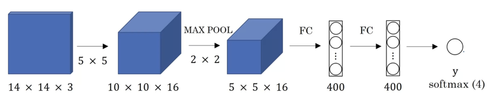

[figure not shown]

The test set image will be larger than the training set since the training set images are cropped. However, we can directly feed the larger image into the model. The final output from the test images will have different sizes and each square contains the output for a specific window position. Thus, the neural network is able to process the entire image in one forward propagation instead of iterating over each window position

[figure not shown]

Issue: sliding window algorithm relies on the window size and stride to detect objects, but most of the time, the window is not a perfect fit as the bounding box

# YOLO

The YOLO algorithm divdes the image into $m \times n$ number of grid cells and assign each object to one and only one cell based on its center. Then, the image will be feed into the sliding window algorithm and predict a output volume of size $m \times n$ with channels in the format of the target label. Each grid cell in the output corresponds to the prediction made on the original grid cell

In this case, $b_x$, $b_y$ represent the cooridnate of the object's center in the cell (only if $p_c=1$) and $b_h$, $b_w$ represent the percentage height and width with respect to the grid cell size. Thus, four values are between 0 and 1

[figure not shown]

## Intersection over union

Intersection over union (IoU) is used to evaluate the model's prediction of the bounding box by computing the ratio between the intersection and the union of the predicted and actual bounding box. The higher the IoU value, the more accurate the prediction

$$IoU = \frac{\text{Size of intersection}}{\text{Size of union}}$$

## Non-max suppression

Non-max suppression is used reduce the number of bounding boxes when we get more than 1 bounding box for a object detection

Steps:

1. Discard all boxes with $p_C$ under a threshold (0.6), which indiates there may be no object
2. For the remaining box, pick the box with largest $p_C$ as prediction for each object and discard all boxes with $IoU$ higher than the threshold (0.5), which indiates two boxes overlap
3. When there are multiple labels, perform non-max suppression for each label individually

[figure not shown]

## Anchor boxes

In some cases, more than one object is assigned to the single grid cell as the mid-point of more objects lies in the same grid cell. In order to handle this problem, we use anchor boxes

Thus the target output will be enlongated with each section correspond to a single anchor box with the highest overlap (IoU)

$$y = \begin{bmatrix} p_{c_1} \\ l_{1_1} \\ l_{2_1} \\ \vdots \\ c_{1_1} \\ c_{2_1}\\ \vdots \\ p_{c_2} \\ l_{1_2} \\ l_{2_2} \\ \vdots \\ c_{1_2} \\ c_{2_2}\\ \vdots \end{bmatrix} $$

$p_{c_1}, l_{1_1}, l_{2_1}, c_{1_1}, c_{2_1} ...$: traget output correspond to the first anchor box

$p_{c_2}, l_{1_2}, l_{2_2}, c_{1_2}, c_{2_2} ...$: traget output correspond to the second anchor box

[figure not shown]

## Yolo algorithm

Feed the model a image and predict a multidimensional output using anchor boxes. Then, use non-max suppression to reduce find the bounding box with the highest IoU for each object

## Region proposal (R-CNN)

Instead of run the sliding window algorithm on the entire image, we first detect the regions that could potentially have an object. Then, feed the image of those region to the model for prediction

# Semantic segmentation (U-net)

Semantic segmentation algorithm can detect objects and defines their boundaries by outputing a matrix with different labels correspond to different nubmers

[figure not shown]

## Transpose convolution:

The size of the tensor will be smaller and smaller deeper in a CNN, so we must use transpose convolution to increase the size of the tensor back up for output. This model is called an encoder/decoder structure, where the network first downsampling the input then upsampling it back up

[figure not shown]

The transpose convolution increases the tensor size by using a filter with size larger than the tensor itself and defined padding and stride size

[figure not shown]

# U-net

The U-net first downsamples the input tensor and then upsamples it to produce the output. However, the details in the input are lost during the downsampling process; adding skip connections between layer can significantly improve the model for more defined boundaries

[figure not shown]

# Face recongnition

- Face verification: given an input image and verify if the input is the claimed person
- Face recongnition: given a database of $K$ person and an input image, output the if the image is a person in the database

## One shot learning

Learning from only one image to recongize the person again

To address this problem, the CNN is trained to learn the difference between two images, $d(img1, img2)$. If the difference between two images is less than a certain threshold, $\tau$, then the person will be verified. If the difference between two images is greater than $\tau$ or no image in the database has a difference less than $\tau$ with the given image, the person will not be verified

## Siamese network

Given a input image, a siamese network will output an vector encoding, $f(x^{(i)})$, of the $i$th image

The difference between the $i$th and the $j$th images, $d(x^{(i)}, x^{(j)})$ is denoted by their norm, where $$d(x^{(i)}, x^{(j)}) = ||x^{(i)} - x^{(j)}||^2$$

If $d(x^{(i)}, x^{(j)})$ is small, the two images are from the same person. If $d(x^{(i)}, x^{(j)})$ is larger, the two images are not from the same person

[figure not shown]

## Triplet loss function

The triple loss function tries to reduce the distance between similar things and increase the distance between different things

Each time, the triplet loss function is trained on an anchor image ($A$) with a fixed identity, a positive image ($P$) with the same identitiy as the $A$, and a negative image ($N$) with different identity as $A$ and $P$

$$ d(A, P) - d(A, N) + \alpha \leq 0 $$ , which is the same as $$ ||f(A) - f(P)||^2 - ||f(A) - f(N)||^2+ \alpha \leq 0 $$

$||f(A) - f(P)||^2$: the difference between the anchor and the positive image

$||f(A) - f(N)||^2$: the difference between the anchor and the negative image

$\alpha$: module, a hyperparameter (positive number) that prevent the model outputing trivial solution (all 0s) or learn the function outputs the same encoding for $f(P)$ and $f(N)$

This function implies that the difference between $A$ and $P$ should be much smaller than $A$ and $N$

Loss function: $$Loss = max(||f(A) - f(P)||^2 - ||f(A) - f(N)||^2+ \alpha, 0)$$

If A, P, N are chosen randomly, the model can easily learn a equation to satisfy the condition, so for the training examples, the A, P, N should be chosen to make it hard to learn (people that look similar) to improve the model's performance

## Face recongintion as binary classification

Instead of using the triplet loss function, we can take compute the enbedding for the input image and an image in the database and feed the two embeddings into a logistic regression unit to identify whether the person is in the database or not

[figure not shown]

For deployment, the encodings for all images in the database can be precomputed to speed up the recongintion process

# Neural style transfer

Given a content image ($C$) and a style image ($S$), the model will output an image $G$ with the content from $C$ and the style of $S$

[figure not shown]

In neural style transfer, instead of training parameters, we train the pixels of the generated image by calculating how similar is the generated image to the content and style image at a particular layer in the network and perform gradient descent

To obtain the encodings of the content of the style image, we take a pretrained network and extract the encoding from a middle layer

## Cost function

The cost function for the generated image, $J(G)$, consists the constent cost, $J_{\text{Content}}(C, G)$,and the style cost,$J_{\text{Style}}(S, G)$, where

$$J(G) = \alpha J_{\text{Content}}(C, G) + \beta J_{\text{Content}}(C, G)$$

$\alpha, \beta$: two hyperparameters that define the relative weighting between the content cost and the style cost

Steps:

1. Randomly generate an image $G$
2. Perform gradient descent to minimize $J(G)$

### Content cost

To compute the content cost, we pass in the content image and the generated image into pretrained network and extract the encodings from the $l$th layer, $a^{[l](C)}$ and $a^{[l](G)}$

The content cost:

$$J_{\text{Content}}(C, G) = \frac{1}{2} ||a^{[l](C)} - a^{[l](G)}||^2 = \frac{1}{4 \times n_H \times n_W \times n_C}\sum _{ \text{all entries}} (a^{[l](C)} - a^{[l](G)})^2$$

$a^{[l](C)}$: the activation (encoding) of the content image from the $l$th layer of the pretrained network

$a^{[l](G)}$: the activation (encoding) of the generated image from the $l$th layer of the pretrained network

Note: $l$ should be somewhere in the middle of the network to ensure that the network detects both higher-level and lower-level features.

### Style cost

To capture the style of an image, we would calculate the correlations between activations across different channels

Each channel is detecting a feature, so if two channels have high correlations, the two features detected by those channels are likely to appear together; if two channels have low correlations, the two features detected by those channels are likely to not appear together

To calculate the correlation between channels, we define the gram matrix for style image, $$G^{[l](S)}_{kk'} = a^{[l](S)}_k * a^{[l](S)}_{k'}$$

$G^{[l](S)}_{kk'}$: the gram matrix of the style image based on the $l$th layer of the pretrained network

$a^{[l](S)}_k * a^{[l](S)}_{k'}$: the dot product of the activation from the $k$th and $k'$th channel

$kk'$: the $k$th and $k'$th channel, where $k, k' = 1, 2, ..., n_C$

Similarly, the gram matrix for generate image is $$G^{[l](G)}_{kk'} = a^{[l](G)}_k * a^{[l](G)}_{k'}$$

The higher the value of $G$, the higher the correlation between two channels

Vectorized implementation by unrolling each channel into a vector

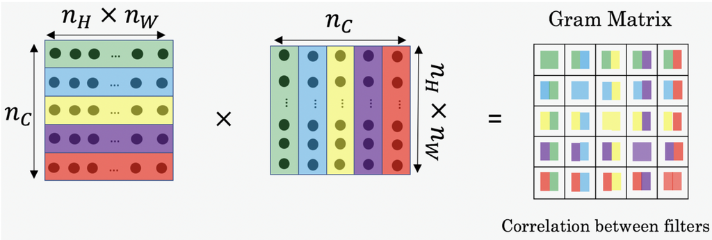

$$\mathbf{G}_{gram} = \mathbf{A}_{unrolled} \mathbf{A}_{unrolled}^T$$

The style cost: $$J_{style}^{[l]}(S,G) = ||G^{[l](S)} - G^{[l](G)}||^2 = \frac{1}{4 \times {n_C}^2 \times (n_H \times n_W)^2} \sum _{i=1}^{n_C}\sum_{j=1}^{n_C}(G^{(S)}_{(gram)i,j} - G^{(G)}_{(gram)i,j})^2$$

We can combine the style costs from multiple layers to better capture both the high level and low level features, weighted by the hyperparameter $\lambda$ for better performance

$$J_{style}(S,G) = \sum_{l} \lambda^{[l]} J^{[l]}_{style}(S,G)$$

## Training

Perform gradient descent on the cost function to update the pixels of the generated image

# Resources

- CS230: https://stanford.edu/~shervine/teaching/cs-230/cheatsheet-convolutional-neural-networks